# Reproducible Research: Peer Assessment 1

Mark Kushelman

### Loading libraries

```r
library(dplyr); library(ggplot2); library(ggpubr)
```

## Loading and preprocessing the data

1. Load the data

```r
activity <- read.csv("activity.csv",colClasses=c("integer","Date","integer"))
dim(activity); names(activity)
```

```
## [1] 17568     3
```

```
## [1] "steps"    "date"     "interval"
```

2. Prepare data
- We use the following denotations:
1. A0 - original activity
2. A1 - subset of A0 with steps which are not NA
3. A2 - subset of A0 with steps which are NA
4. B0, B1, B2 - data sets which are gotten from A0, A1, A2 correspondingly by the following dplyr functions: at first, ‘group by date’ and then ‘summarize using sum’
5. C0 - data sets which are gotten from A0 by the following dplyr functions: at first, ‘group by interval’ and then ‘summarize using mean’

```r
A0 <- activity
GroupByDateA0 <- group_by(A0, date)
SumStepsPerDayA0 <- summarize(GroupByDateA0, SUM=sum(steps, na.rm=TRUE))
B0 <- SumStepsPerDayA0
GroupByIntervalA0 <- group_by(A0, interval)
MeanStepsPerIntervalA0 <- summarize(GroupByIntervalA0, MEAN=mean(steps, na.rm=TRUE))
C0 <- MeanStepsPerIntervalA0

A1 <- filter(activity, !is.na(activity$steps))
GroupByDateA1 <- group_by(A1, date)
SumStepsPerDayA1 <- summarize(GroupByDateA1, SUM=sum(steps, na.rm=TRUE))
B1 <- SumStepsPerDayA1

A2 <- filter(activity, is.na(activity$steps))
GroupByDateA2 <- group_by(A2, date)
SumStepsPerDayA2 <- summarize(GroupByDateA2, SUM=sum(steps, na.rm=TRUE))
B2 <- SumStepsPerDayA2
```

- Check date in B0, B1 and B2  
  By definition, is should be number of dates in B0 is equal number of dates in B1 plus number of dates in B2

```r
N0 <- nrow(B0); N1 <- nrow(B1); N2 <- nrow(B2) ## N0, N1, N2 are numbers of dates in B0, B1, B2
print(paste0("N0 = ",N0)); print(paste0("N1 = ",N1)); print(paste0("N2 = ",N2))
```

```
## [1] "N0 = 61"
```

```
## [1] "N1 = 53"
```

```
## [1] "N2 = 8"
```

Really N0 = N1 + N2.

Because N2 is small we can see the dates in B2:

```r
print("Dates in B2:"); c(B2$date)
```

```
## [1] "Dates in B2:"
```

```
## [1] "2012-10-01" "2012-10-08" "2012-11-01" "2012-11-04" "2012-11-09"
## [6] "2012-11-10" "2012-11-14" "2012-11-30"
```

By the way we can note that the date column in B1 starts from 2012-10-02 (because the date column in B2 starts from 2012-10-01)

## What is mean total number of steps taken per day?

For this part of the assignment, you can ignore the missing values in the dataset.

**It means that for this part we continue with `B1`**

1. Calculate the total number of steps taken per day
- Now we prepare `B1` for histograms.

```r
Month <- format(B1$date,"%m")
B1$month <- as.numeric(Month)
```

2. Make a histogram of the total number of steps taken each day

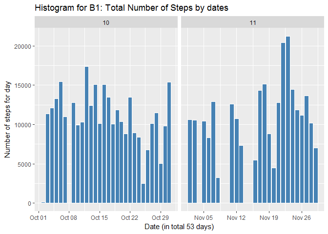

```r
GG <- ggplot(B1, aes(date, SUM))+
    geom_col(colour = "white", fill = "steelblue") +
    facet_grid(. ~ month, scales = "free") +
    ggtitle("Histogram for B1: Total Number of Steps by dates")+
    xlab("Date (in total 53 days)")+ylab("Number of steps for day")
GG
```

```r
## Save the plot into pgn file
ggsave(filename <- "Histogram for B1.png", GG, width = 9, height = 6, dpi = 120, units = "in", device='png')
unlink(filename)
```

3. Calculate and report the mean and median of the total number of steps taken per day

```r
m1 <- round(mean(B1$SUM),2)
m2 <- round(median(B1$SUM),2)
print(paste0("For B1 mean=", m1,"; median=",m2))
```

```
## [1] "For B1 mean=10766.19; median=10765"
```

## What is the average daily activity pattern?

1. Make a time series plot of the 5-minute interval (x-axis) and the average number of steps taken, averaged across all days (y-axis)
- Note: This average **(mean)** is taken across all days in **October and November** for each 5-minute interval.

**By definition it is the `C0` data set**

```r
head(C0)
```

```
## # A tibble: 6 x 2
##   interval   MEAN
##      <int>  <dbl>
## 1        0 1.72
## 2        5 0.340
## 3       10 0.132
## 4       15 0.151
## 5       20 0.0755
## 6       25 2.09
```

- Time series plot

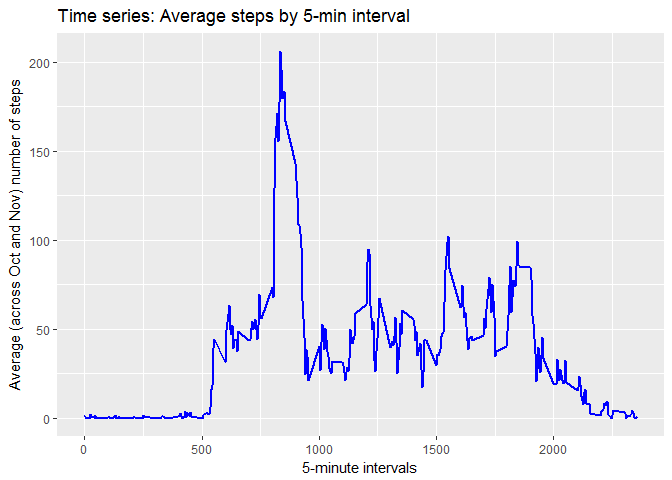

```r
GG <- ggplot(C0,aes(x=interval,y=MEAN))+ geom_line(color = "blue", size = 0.9)+
    ggtitle("Time series: Average steps by 5-min interval")+
    xlab("5-minute intervals") +
    ylab("Average (across Oct and Nov) number of steps")
GG
```

```r
## Save the plot into pgn file
ggsave(filename <- "Time series.png", GG, width = 9, height = 6, dpi = 120, units = "in", device='png')
unlink(filename)
```

2. Which 5-minute interval, on average across all the days in the dataset, contains the maximum number of steps?

```r
MAX <- max(C0$MEAN)
f <- filter (C0, MEAN == MAX)
print(paste0("The interval ",f$interval," contains this ",round(f$MEAN,2)," required maximum"))
```

```
## [1] "The interval 835 contains this 206.17 required maximum"
```

## Imputing missing values

1. Calculate and report the total number of missing values in the dataset (i.e. the total number of rows with **NA**s)

```r
print(paste0("The total number of missing values is ", sum(is.na(A0$steps))))
```

```
## [1] "The total number of missing values is 2304"
```

2. Devise a strategy for filling in all of the missing values in the dataset. The strategy does not need to be sophisticated. For example, you could use the mean/median for that day, or the mean for that 5-minute interval, etc.  
   **Rule: For filling NA in `steps` we use the average for the steps in the `B1` data set.**
3. Create a new dataset that is equal to the original dataset but with the missing data filled in.
- Plan:
1. For above average we use mean `x` for steps in `B1`
2. Fill in all `B2` steps with `x`
3. Bind `B1` with `B2`

```r
D1 <- B1
D2 <- B2
## Step 1
x = mean(D1$SUM)
## Step 2
D2$SUM <- rep(x,nrow(D2))
Month <- format(D2$date,"%m")
D2$month <- as.numeric(Month)
## Step 3
D0 <- rbind(D1, D2)
D0 <- arrange(D0, date)
head(D0)
```

```
## # A tibble: 6 x 3
##   date         SUM month
##   <date>     <dbl> <dbl>
## 1 2012-10-01 10766  10.0
## 2 2012-10-02   126  10.0
## 3 2012-10-03 11352  10.0
## 4 2012-10-04 12116  10.0
## 5 2012-10-05 13294  10.0
## 6 2012-10-06 15420  10.0
```

Now we prepare `B0` and `D0` for graphs.

```r
B <- B0
Month <- format(B$date,"%m")
B$month <- as.numeric(Month)
B$type <- rep("B",nrow(B))
D0$type <- rep("D0",nrow(D0))
rbind.B.and.D0 <- rbind(B, D0)
```

- Build 2 histograms and 1 plot

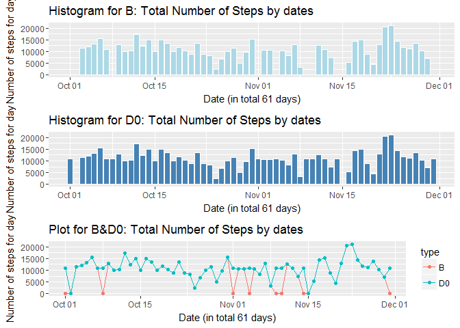

```r
g0 <- ggplot(B, aes(date, SUM))+
    geom_col(colour = "white", fill = "lightblue")+
    ggtitle("Histogram for B: Total Number of Steps by dates")+
    xlab("Date (in total 61 days)")+ylab("Number of steps for day")

g1 <- ggplot(D0, aes(date, SUM))+
    geom_col(colour = "white", fill = "steelblue")+
    ggtitle("Histogram for D0: Total Number of Steps by dates")+
    xlab("Date (in total 61 days)")+ylab("Number of steps for day")

g <- qplot(date, SUM, data = rbind.B.and.D0, colour=type, geom = c("line","point"))+
    ggtitle("Plot for B&D0: Total Number of Steps by dates")+
    xlab("Date (in total 61 days)")+
    ylab("Number of steps for day")

GG <- ggarrange(g0, g1, g, ncol = 1, nrow = 3)
GG
```

On the `type B` plot we see 8 points with 0 values. These values correspond to all 8 dates in `B2`. Values for these dates in `type D0` plot are 10766.19 which is `x` from the Step 1 of above Plan.

```r
## Save the plot into pgn file
ggsave(filename <- "3 graphs.png", GG, width = 9, height = 7, dpi = 120, units = "in", device='png')
unlink(filename)
```

```r
print(paste0("For B mean=", round(mean(B$SUM),2),"; median=",round(median(B$SUM),2)))
```

```
## [1] "For B mean=9354.23; median=10395"
```

```r
print(paste0("For D0 mean=", round(mean(D0$SUM),2),"; median=",round(median(D0$SUM),2)))
```

```
## [1] "For D0 mean=10766.19; median=10766.19"
```

**The mean/median for B differ from the mean/median for D0**

## Are there differences in activity patterns between weekdays and weekends?

1. Create a new factor variable in the dataset with two levels - “weekday” and “weekend” indicating whether a given date is a weekday or weekend day.

```r
W <- A0
WeekDay <- format(W$date,"%A")
W$WeekDayEnd <- as.factor(WeekDay)

levels(W$WeekDayEnd) <- list(
    weekday = c("Monday","Tuesday","Wednesday","Thursday","Friday"),
    weekend = c("Saturday", "Sunday"))

levels(W$WeekDayEnd)
```

```
## [1] "weekday" "weekend"
```

```r
names(W)
```

```
## [1] "steps"      "date"       "interval"   "WeekDayEnd"
```

```r
distinct(W,WeekDayEnd)
```

```
##   WeekDayEnd
## 1    weekday
## 2    weekend
```

2. Make a panel plot containing a time serises plot (i.e. type = “l”) of the 5-minute interval (x-axis) and the average number of steps taken, averaged across all weekday days or weekend days (y-axis).
- Prepare the `A0` set for the plot (using mean for average). The prepared set is `WeekDayEnd`

```r
WeekDay <- filter(W, WeekDayEnd == "weekday")
WeekEnd <- filter(W, WeekDayEnd == "weekend")

GroupByIntervalWeekDay <- group_by(WeekDay, interval)
GroupByIntervalWeekEnd <- group_by(WeekEnd, interval)

MeanStepsPerIntervalWeekDay <- summarize(GroupByIntervalWeekDay, MEAN=mean(steps, na.rm=TRUE))
MeanStepsPerIntervalWeekEnd <- summarize(GroupByIntervalWeekEnd, MEAN=mean(steps, na.rm=TRUE))

WeekDay <- MeanStepsPerIntervalWeekDay
WeekEnd <- MeanStepsPerIntervalWeekEnd
v <-  rep("weekday",nrow(WeekDay))
WeekDay$type <- v
v <-  rep("weekend",nrow(WeekEnd))
WeekEnd$type <- v

# WeekDayEndC0 <- rbind(WeekDay,WeekEnd)
rBind <- rbind(WeekDay,WeekEnd)
WeekDayEnd <- group_by(rBind, type)
```

- Plot the `WeekDayEnd`

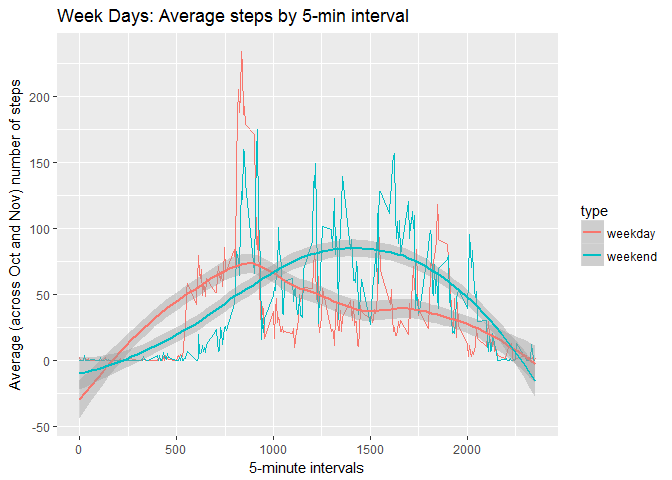

```r
GG <- qplot(interval, MEAN, data = WeekDayEnd, colour=type, geom = c("line","smooth"))+
    ggtitle("Week Days: Average steps by 5-min interval")+
    xlab("5-minute intervals")+
    ylab("Average (across Oct and Nov) number of steps")
GG
```

```r
## Save the plot into pgn file
ggsave(filename <- "Week Days.png", GG, width = 9, height = 6, dpi = 120, units = "in", device='png')
unlink(filename)
```